# Bayesian Classification of the Canadian Hondius-Linked Case

Decision support for whether the Canadian case is second- or third-generation

Author

Billy Quilty

Published

May 17, 2026

# 1 Summary

** Note: analysis up to date as of 17 May 2026 **

A Bayesian classification of a Canadian Andes virus case (symptom onset 14 May 2026, confirmed positive 15 May 2026) assessed whether infection was generation 2 (direct from Hondius case 1) or generation 3 (from the onboard cluster). Applying the Epuyén timing posterior from Funk and Abbott (Funk and Abbott 2026; Martínez et al. 2020) to the Hondius line list (Global.health 2026), the baseline analysis gave posterior support of 73.9% (52.9%–91.1%) for generation 3 against 26.1% (8.9%–47.1%) for generation 2 (Public Health Agency of Canada 2026; World Health Organization 2026a, 2026b). The peak generation-3 exposure date was 27 Apr 2026. Posterior support for generation 3 provides additional evidence of human-to-human transmission within the Hondius cluster beyond the initial case.

# 2 Introduction

The Hondius outbreak immediately raised the question of whether exported cases represented direct descent from the index case or onward spread within the shipboard cluster (World Health Organization 2026a, 2026b). For the Canadian case, generation 2 implies direct infection from case 1; generation 3 implies the cluster had already amplified before disembarkation (Public Health Agency of Canada 2026). This report addresses that classification question; full transmission-tree reconstruction is out of scope.

A critical prior assumption underlies the entire analysis: that human-to-human (H2H) transmission of Andes virus occurred within the Hondius cluster — specifically, that case 1 infected other passengers via H2H contact (generating the onboard secondary cluster), and that one or more of those generation-2 cases could have in turn infected the Canadian case. H2H transmission is a well-documented and distinctive feature of Andes virus (Martínez et al. 2020), and the scale and epidemiological pattern of the Hondius cluster is consistent with ongoing shipboard H2H spread (World Health Organization 2026a, 2026b). If the Hondius cases were instead independent zoonotic spillover events, the generation-2/3 distinction used here would not apply.

# 3 Results

The baseline posterior strongly favoured generation 3: 73.9% (52.9%–91.1%) versus 26.1% (8.9%–47.1%) for generation 2 (Table 1). Peak exposure support fell on 06 Apr 2026 under generation 2 and 27 Apr 2026 under generation 3 (Figure 1; Figure 2), the latter closely matching the late-April onboard onset wave (see Figure 3 in the Supplement).

Table 1: Baseline posterior probabilities for the two competing assumed generations.

| Assumed generation | Posterior median | 95% credible interval | Evaluated exposure range |
| --- | --- | --- | --- |
| Generation 2 | 26.1% | 8.9% to 47.1% | 01 Apr 2026 to 11 Apr 2026 |
| Generation 3 | 73.9% | 52.9% to 91.1% | 17 Apr 2026 to 10 May 2026 |

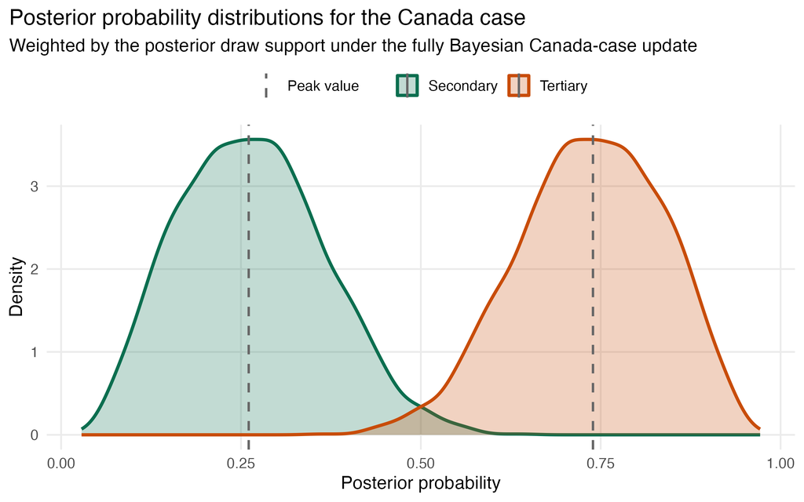

Figure 1: Baseline posterior density for the two competing assumed generations.

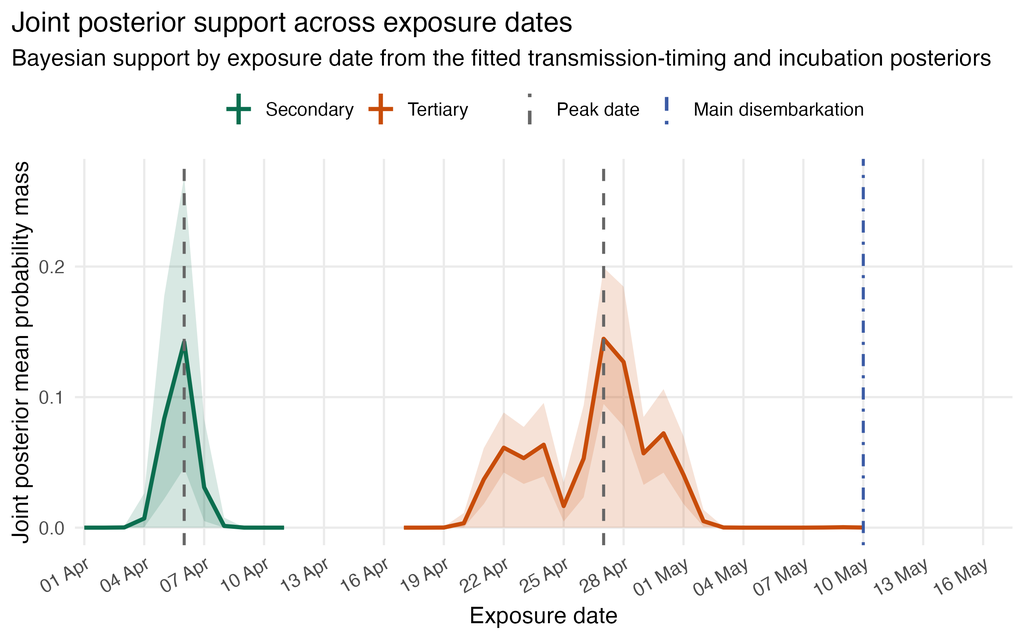

Figure 2: Joint posterior support across exposure dates under the baseline analysis.

No alternative scenario reversed the ordering. Full sensitivity results are in the Supplement (Figure 4; Table 4).

The generation-2 hypothesis has a single candidate source (case 1, onset 06 Apr 2026); the generation-3 hypothesis averages over 10 candidates spanning 22 Apr 2026 to 10 May 2026.

# 4 Discussion

The Canadian case is more consistent with a third-generation infection from the onboard cluster than directly from case 1, despite the reportedly long incubation period; the observed onset on 14 May aligns more closely with late-April onboard sources, not with the generation-2 window anchored to case 1.

The result holds across all sensitivity scenarios. Two structural qualifications remain. First, the generation-3 hypothesis has 10 candidate sources against one for generation 2; the broader candidate set provides more flexibility to match the observed onset, which could inflate its marginal likelihood relative to a penalty-adjusted comparison. Second, several late-onset candidates-including cases whose onset coincided with the Tenerife disembarkation on 10 May – may have been hospitalised before contact with the Canadian case was possible; excluding them would concentrate support on mid-to-late April cases and, if anything, reinforce the generation-3 signal. This remains a classification analysis rather than a full transmission-tree reconstruction.

# 5 Methods

Incubation period and transmission interval distributions for Andes virus were taken from Funk and Abbott’s Bayesian re-estimation of the 2018–19 Epuyén outbreak (Funk and Abbott 2026; Martínez et al. 2020), which yielded a posterior with median incubation log-mean 3.064, log-SD 0.319, transmission-interval mean 0.176 days, and SD 0.611 days.

Hondius case data came from the Kraemer Lab line list (Global.health 2026); public health context from PHAC and WHO statements (Public Health Agency of Canada 2026; World Health Organization 2026a, 2026b). Case 1 was treated as the sole generation-1 source; all other onset-documented cases were candidate generation-2 sources; the Canadian case was evaluated as either generation 2 or generation 3.

For each hypothesis, the marginal likelihood of the observed Canadian onset (14 May 2026) was computed by integrating over candidate source cases and exposure dates within the hypothesis-specific window (Table 3). Each (source, exposure date) pair was weighted by the joint probability under the transmission interval distribution (source onset → exposure date) and the incubation distribution (exposure date → Canadian onset). Uncertainty in the epidemiological parameters was propagated by averaging over draws from the Epuyén posterior. The two hypotheses were assigned equal prior weight; posterior probabilities were obtained by normalising the resulting marginal likelihoods. The exposure window lower bound was set to the earliest source onset minus a padding constant (default five days, capturing plausible pre-symptomatic transmission). Sensitivity analyses used three- and seven-day padding, and a further scenario restricted generation-3 sources to confirmed cases only.

The upstream Epuyén model assigned each case latent infection and onset times, modelled incubation log-normally, transmission timing as normal, offspring counts with a negative-binomial component, and the time-varying reproduction number as a log-scale random walk (Funk and Abbott 2026; Martínez et al. 2020). Principal priors are listed in Table 2; the two competing hypotheses are defined in Table 3.

Table 2: Bayesian priors used in the Epuyén re-estimation by Funk and Abbott.

| Quantity | Distribution | Prior |
| --- | --- | --- |
| Incubation log-mean, μ_inc | Normal | Normal(3.0, 0.5) |
| Incubation log-SD, σ_inc | half-Normal | Normal(0, 0.5), truncated at > 0 |
| Transmission-timing mean, μ_δ | Normal | Normal(0, 5) |
| Transmission-timing SD, σ_δ | half-Normal | Normal(0, 1), truncated at > 0 |
| Offspring dispersion, k | half-Normal | Normal(0.3, 0.5), truncated at > 0 |
| Initial log reproduction number | Normal | Normal(log(1.5), 1) |
| Weekly log R(t) innovations | half-Normal | Normal(0, 0.5), truncated at > 0 |

Table 3: Definition of the two competing assumed generations and the source data that support them.

| Assumed generation | Candidate source cases | Source onset range | Evaluated exposure range | Rationale |
| --- | --- | --- | --- | --- |
| Generation 2 | 1 | 06 Apr 2026 to 06 Apr 2026 | 01 Apr 2026 to 11 Apr 2026 | Case 1 is treated as the generation-1 onboard source. Under this hypothesis, the Canadian case is generation 2 and its infection date is inferred by combining the fitted transmission-timing posterior … |
| Generation 3 | 10 | 22 Apr 2026 to 10 May 2026 | 17 Apr 2026 to 10 May 2026 | All onset-documented Hondius cases other than case 1 are treated as generation 2. Under this hypothesis, the Canadian case is generation 3 and its infection date is inferred by averaging over those ca… |

# 6 Data Availability

The Hondius case data used in this analysis are from the Kraemer Lab curated line list(Global.health 2026). The line list draws on: WHO Disease Outbreak News (World Health Organization 2026a, 2026b), UKHSA (UK Health Security Agency 2026), BBC News (BBC News 2026), and AP News (AP News 2026). The Epuyén outbreak line list underlying the Funk and Abbott posterior is from Martínez and colleagues (Martínez et al. 2020). All data and code for this report are available at the project repository.

# 7 Supplement

## 7.1 Case event timeline

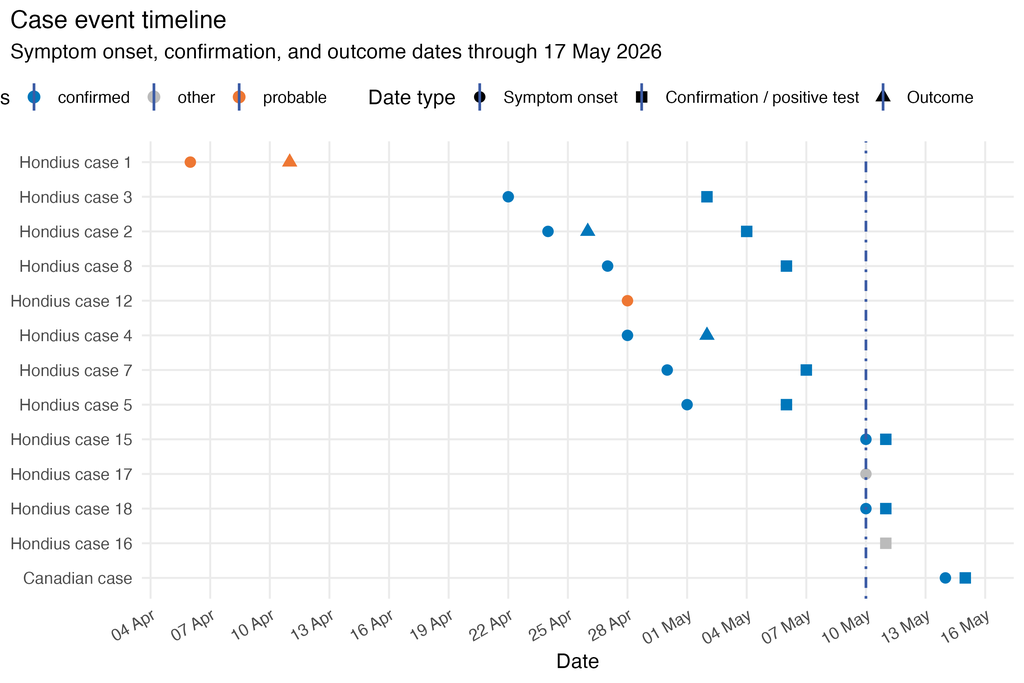

Figure 3: Symptom onset, confirmation, and outcome dates for Hondius cases and the Canadian case.

## 7.2 Sensitivity analyses

Source-onset shifts of ±1 day gave generation-3 posteriors of 78.1% and 68.7%; a two-fold prior preference for generation 2 gave 57.5%; three- and seven-day exposure-window padding gave 71.5% and 75.6%. Restricting to confirmed generation-3 sources gave 75.0%.

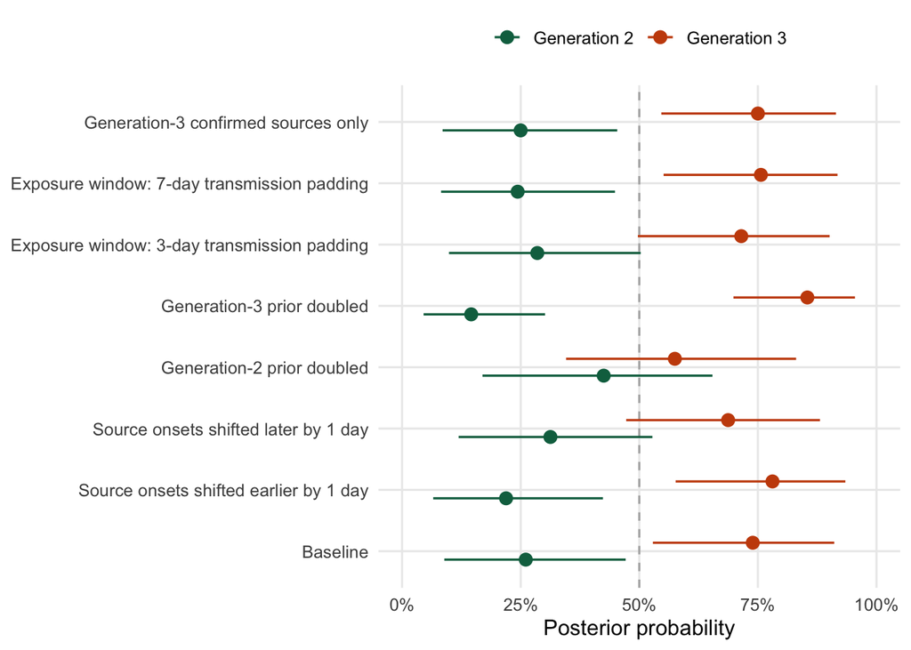

Figure 4: Posterior medians and 95% credible intervals across baseline and sensitivity scenarios.

Table 4: Sensitivity analysis: posterior medians and 95% credible intervals under alternative onset shifts, prior weights, and exposure-window padding.

| Scenario | Generation 2 | Generation 3 |
| --- | --- | --- |
| Baseline | 26.1% (8.9% to 47.1%) | 73.9% (52.9% to 91.1%) |
| Source onsets shifted earlier by 1 day | 21.9% (6.6% to 42.3%) | 78.1% (57.7% to 93.4%) |
| Source onsets shifted later by 1 day | 31.3% (11.9% to 52.8%) | 68.7% (47.2% to 88.1%) |
| Generation-2 prior doubled | 42.5% (16.9% to 65.4%) | 57.5% (34.6% to 83.1%) |
| Generation-3 prior doubled | 14.6% (4.5% to 30.1%) | 85.4% (69.9% to 95.5%) |
| Exposure window: 3-day transmission padding | 28.5% (9.9% to 50.3%) | 71.5% (49.7% to 90.1%) |
| Exposure window: 7-day transmission padding | 24.4% (8.2% to 44.9%) | 75.6% (55.1% to 91.8%) |
| Generation-3 confirmed sources only | 25.0% (8.5% to 45.4%) | 75.0% (54.6% to 91.5%) |

## 8 References

AP News. 2026. “Hantavirus Outbreak Linked to Hondius Cruise Ship.” https://apnews.com/article/hantavirus-outbreak-hondius-cruise-ship-df0e7e1fb9c7fd3e4092be06e684f644.

BBC News. 2026. “Hantavirus Outbreak: Live Coverage.” https://www.bbc.com/news/live/cy592qeq071t.

Funk, Sebastian, and Sam Abbott. 2026. “Andes Virus: Joint Estimation of Incubation, Transmission Timing, and R(t).” https://epiforecasts.io/andv-linelist-analysis/dev.

Global.health. 2026. “Global.health: Hondius Hantavirus 2026 Outbreak Data [2026-05-17].” GitHub repository, accessed 2026-05-17. https://github.com/kraemer-lab/Hondius_hantavirus_h2026.

Martínez, Valeria P., Natalia Di Paola, Daniel O. Alonso, Norma Pini, Gustavo Santillán, Marta Contigiani, Pablo Angeleri, et al. 2020. “"Super-Spreaders" and Person-to-Person Transmission of Andes Virus in Argentina.” *New England Journal of Medicine* 383 (23): 2230–41. https://doi.org/10.1056/NEJMoa2009040.

Public Health Agency of Canada. 2026. “Media Update on Andes Hantavirus Situation.” https://www.canada.ca/en/public-health/news/2026/05/media-update-on-andes-hantavirus-situation0.html.

UK Health Security Agency. 2026. “UK Government Statement on the Hantavirus Situation Linked to MV Hondius.” https://ukhsa-newsroom.prgloo.com/news/uk-government-statement-from-the-uk-health-security-agency-ukhsa-department-for-health-and-social-care-dhsc-and-foreign-commonwealth-and-development-office-fcdo-8th-may-2026.

World Health Organization. 2026a. “Disease Outbreak News: Andes Hantavirus Linked to the MV Hondius.” https://www.who.int/emergencies/disease-outbreak-news/item/2026-DON600.

———. 2026b. “Disease Outbreak News: Andes Hantavirus Linked to the MV Hondius Update.” https://www.who.int/emergencies/disease-outbreak-news/item/2026-DON601.